# Predict Diabetes

Huynh | Ravindra | Sood | Swamykannu

## Synopsis

The data was collected and made available by "National Institute of Diabetes and Digestive and Kidney Diseases. Our project focuses on factors which affect the likelihood of person getting the diabetes.

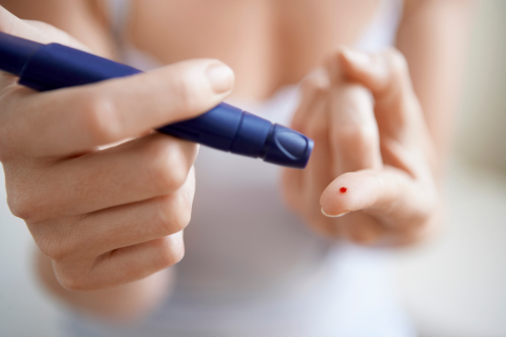

## Packages Required

```r
library(readxl)
library(kableExtra)
library(corrplot)
library(dplyr)
library(ggplot2)
library(GGally)
library(tidyr)
library(DT)
library(gridExtra)
library(ROCR)
packages <- read_excel("D:/Documents/GitHub/DAM_project2/Packages.xlsx")
kable(packages)%>%
kable_styling( bootstrap_options = c("striped", "responsive"))
```

| Package | Function |
| --- | --- |
| library(GGally) | GGally extends ggplot2 by adding several functions to reduce the complexity |
| library(tidyr) | For changing the layout of your data sets, to convert data into the tidy format |
| library(DT) | For HTML display of data |
| library(ggplot2) | For customizable graphical representation |
| library(dplyr) | For data manipulation |
| library(tidyverse) | Collection of R packages designed for data science that works harmoniously with other packages |
| library(kableExtra) | To display table in a fancy way |
| library(corrplot) | To create the coorelation plot |

## Data Preparation

### Data Source

The link to original dataset can be found [here](https://www.kaggle.com/kandij/diabetes-dataset) This dataset contains 768 rows and 9 columns.

```r
data <- read.csv("D:/Documents/GitHub/DAM_project2/diabetes2.csv", stringsAsFactors = FALSE, header = TRUE)
head(data)
```

```
##   Pregnancies Glucose BloodPressure SkinThickness Insulin  BMI
## 1           6     148            72            35       0 33.6
## 2           1      85            66            29       0 26.6
## 3           8     183            64             0       0 23.3
## 4           1      89            66            23      94 28.1
## 5           0     137            40            35     168 43.1
## 6           5     116            74             0       0 25.6
##   DiabetesPedigreeFunction Age Outcome
## 1                    0.627  50       1
## 2                    0.351  31       0
## 3                    0.672  32       1
## 4                    0.167  21       0
## 5                    2.288  33       1
## 6                    0.201  30       0
```

```r
nrow(data)
```

```
## [1] 768
```

```r
ncol(data)
```

```
## [1] 9
```

```r
colnames(data)
```

```
## [1] "Pregnancies"              "Glucose"
## [3] "BloodPressure"            "SkinThickness"
## [5] "Insulin"                  "BMI"
## [7] "DiabetesPedigreeFunction" "Age"
## [9] "Outcome"
```

We can understand more about the structure of the dataset by using the str() function.

```r
str(data)
```

```
## 'data.frame':    768 obs. of  9 variables:
##  $ Pregnancies             : int  6 1 8 1 0 5 3 10 2 8 ...
##  $ Glucose                 : int  148 85 183 89 137 116 78 115 197 125 ...
##  $ BloodPressure           : int  72 66 64 66 40 74 50 0 70 96 ...
##  $ SkinThickness           : int  35 29 0 23 35 0 32 0 45 0 ...
##  $ Insulin                 : int  0 0 0 94 168 0 88 0 543 0 ...
##  $ BMI                     : num  33.6 26.6 23.3 28.1 43.1 25.6 31 35.3 30.5 0 ...
##  $ DiabetesPedigreeFunction: num  0.627 0.351 0.672 0.167 2.288 ...
##  $ Age                     : int  50 31 32 21 33 30 26 29 53 54 ...
##  $ Outcome                 : int  1 0 1 0 1 0 1 0 1 1 ...
```

These 8 variables are indicators taken to consideration of getting diabietes. The ‘Outcome’ is a response variable stated whether a person has diabetes or not by showing “0” for NO and “1” for Yes.

### Data Cleaning

Checking for missing value and NULL value in the given dataset is one of the crucial steps in data cleaning

```r
    any(is.na(data))
```

```
## [1] FALSE
```

```r
    any(is.null(data))
```

```
## [1] FALSE
```

The result is False so we do not have to worry about the missing values and NULL value might affects building our model later on. Next step, we have to search for dupplicated records in the data set.

```r
duplicate_value <- data[duplicated(data),]
head(unique(data))
```

```
##   Pregnancies Glucose BloodPressure SkinThickness Insulin  BMI
## 1           6     148            72            35       0 33.6
## 2           1      85            66            29       0 26.6
## 3           8     183            64             0       0 23.3
## 4           1      89            66            23      94 28.1
## 5           0     137            40            35     168 43.1
## 6           5     116            74             0       0 25.6
##   DiabetesPedigreeFunction Age Outcome
## 1                    0.627  50       1
## 2                    0.351  31       0
## 3                    0.672  32       1
## 4                    0.167  21       0
## 5                    2.288  33       1
## 6                    0.201  30       0
```

```r
sapply(data, function(x) length(unique(x)))
```

```
##              Pregnancies                  Glucose            BloodPressure
##                       17                      136                       47
##            SkinThickness                  Insulin                      BMI
##                       51                      186                      248
## DiabetesPedigreeFunction                      Age                  Outcome
##                      517                       52                        2
```

The next thing we need to look for is the outliers of each variable.

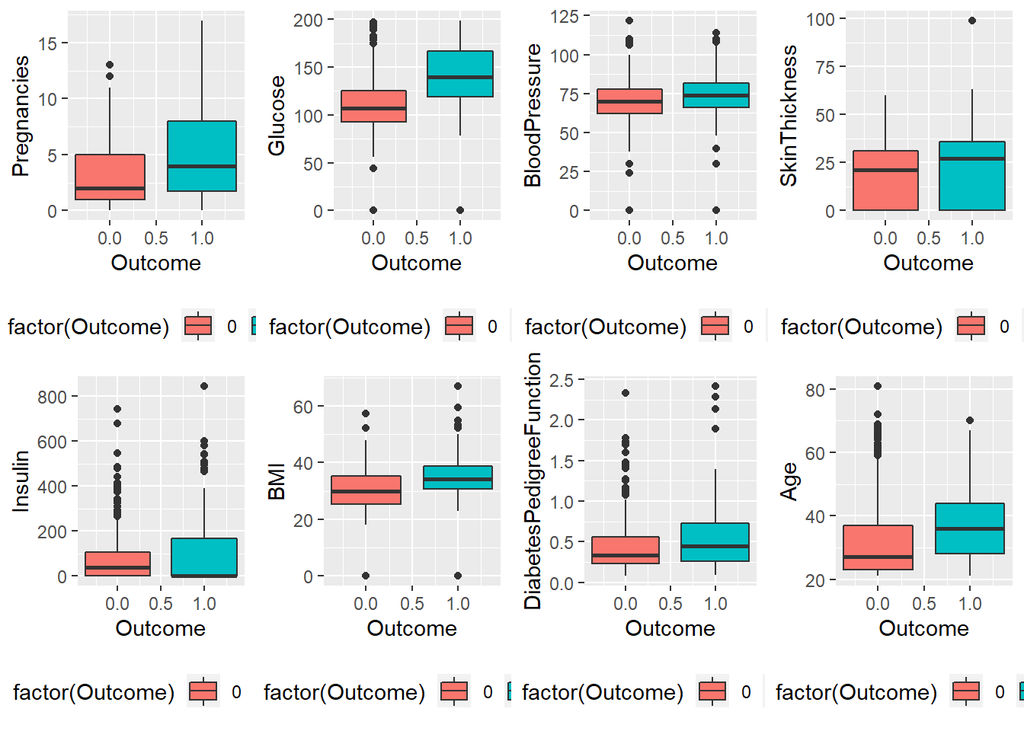

```r
a <- ggplot(data, aes(x= Outcome, y= Pregnancies, fill = factor(Outcome))) + geom_boxplot() + theme(legend.position = "bottom")
b<- ggplot(data, aes(x= Outcome, y= Glucose, fill = factor(Outcome))) + geom_boxplot() + theme(legend.position = "bottom")
c<- ggplot(data, aes(x= Outcome, y= BloodPressure , fill = factor(Outcome))) + geom_boxplot() + theme(legend.position = "bottom")
d<- ggplot(data, aes(x= Outcome, y= SkinThickness , fill = factor(Outcome))) + geom_boxplot() + theme(legend.position = "bottom")
e<- ggplot(data, aes(x= Outcome, y= Insulin, fill = factor(Outcome))) + geom_boxplot() + theme(legend.position = "bottom")
f<- ggplot(data, aes(x= Outcome, y= BMI, fill = factor(Outcome))) + geom_boxplot() + theme(legend.position = "bottom")
g<- ggplot(data, aes(x= Outcome, y= DiabetesPedigreeFunction, fill = factor(Outcome))) + geom_boxplot() + theme(legend.position = "bottom")
h<- ggplot(data, aes(x= Outcome, y= Age, fill = factor(Outcome))) + geom_boxplot() + theme(legend.position = "bottom")
grid.arrange(a,b,c,d,e,f,g,h, ncol=4)
```

We can see that women with non diabetes (outcome =0) has fewer number of pregnancies compared to the diabetes group and is skew to the right. The diabetes women group have higher Glucose concentration. The two group have quite similar blood pressure measurement. There are many outliers in Insulin from both women groups, especially women with diabetes is heavily skewed to the right. Women with diabetes have slightly higher BMI than the other.The pedigree function distribution in both groups have outliers and have positive skew.The average age of women in diabetes group seems older than women in non diabetes group.

In reality, living organisms can’t have zero value for their blood pressure. We will check if there how many rows that contains 0 value in Blood Pressure.

```r
sum(data$BloodPressure==0)
```

```
## [1] 35
```

With fasting glucose levels would not be as low as zero. Therefore zero is an invalid reading. We will check if there how many rows that contains 0 value in Glucose.

```r
sum(data$Glucose==0)
```

```
## [1] 5
```

For normal people, skin fold thickness can’t be less than 10 mm better yet zero. We will check if there how many rows that contains 0 value.

```r
sum(data$SkinThickness==0)
```

```
## [1] 227
```

So a fasting insulin level should never be 0, which it might be in a person with untreated Type 1. It shouldn’t go below 3. We will check if there how many rows that contains 0 value.

```r
sum(data$Insulin==0)
```

```
## [1] 374
```

BMI can’t be or close to 0 cause it is not reality related. We will check if there how many rows that contains 0 value.

```r
sum(data$BMI==0)
```

```
## [1] 11
```

With the domain knowledge checking, we found invalid values in some columns. We conclude that the given data set is imcomplete. This leads to our group decision to use imputation to make the data set more relevant and reasonable. We should replace the rows contained zero value in blood pressure, glucose, skin thickness, insulin and BMI variables with the median value to keep the our dataset logically.

```r
# People with no diabetes an zero blood pressure values

non_diabetic <- which(data$BloodPressure==0 & data$Outcome==0)
temp_median <- median(data$BloodPressure[!data$BloodPressure==0 & data$Outcome==0])
data$BloodPressure[non_diabetic] <- temp_median
temp_median
```

```
## [1] 70
```

```r
# People with diabetes an zero blood pressure values
diabetic <- which(data$BloodPressure==0 & data$Outcome==1)
data$BloodPressure[diabetic] <- median(data$BloodPressure[!data$BloodPressure==0 & data$Outcome==1])

# People with no diabetes an zero Glucose values
non_diabetic <- which(data$Glucose==0 & data$Outcome==0)
data$Glucose[non_diabetic] <- median(data$Glucose[!data$Glucose==0 & data$Outcome==0])

# People with diabetes an zero Glucose values
diabetic <- which(data$Glucose==0 & data$Outcome==1)
data$Glucose[diabetic] <- median(data$Glucose[!data$Glucose==0 & data$Outcome==1])

# People with no diabetes an zero Skin Thickness values
non_diabetic <- which(data$SkinThickness==0 & data$Outcome==0)
data$SkinThickness[non_diabetic] <- median(data$SkinThickness[!data$SkinThickness==0 & data$Outcome==0])

# People with diabetes an zero Skin Thickness values
diabetic <- which(data$SkinThickness==0 & data$Outcome==1)
data$SkinThickness[diabetic] <- median(data$SkinThickness[!data$SkinThickness==0 & data$Outcome==1])

# People with no diabetes an zero Insulin values
non_diabetic <- which(data$Insulin==0 & data$Outcome==0)
data$Insulin[non_diabetic] <- median(data$Insulin[!data$Insulin==0 & data$Outcome==0])

# People with diabetes an zero Insulin values
diabetic <- which(data$Insulin==0 & data$Outcome==1)
data$Insulin[diabetic] <- median(data$Insulin[!data$Insulin==0 & data$Outcome==1])

# People with no diabetes an zero BMI values
non_diabetic <- which(data$BMI==0 & data$Outcome==0)
data$BMI[non_diabetic] <- median(data$BMI[!data$BMI==0 & data$Outcome==0])

# People with diabetes an zero BMI values
diabetic <- which(data$BMI==0 & data$Outcome==1)
data$BMI[diabetic] <- median(data$BMI[!data$BMI==0 & data$Outcome==1])

summary(data)
```

```
##   Pregnancies        Glucose       BloodPressure    SkinThickness
##  Min.   : 0.000   Min.   : 44.00   Min.   : 24.00   Min.   : 7.00
##  1st Qu.: 1.000   1st Qu.: 99.75   1st Qu.: 64.00   1st Qu.:25.00
##  Median : 3.000   Median :117.00   Median : 72.00   Median :28.00
##  Mean   : 3.845   Mean   :121.68   Mean   : 72.39   Mean   :29.09
##  3rd Qu.: 6.000   3rd Qu.:140.25   3rd Qu.: 80.00   3rd Qu.:32.00
##  Max.   :17.000   Max.   :199.00   Max.   :122.00   Max.   :99.00
##     Insulin           BMI        DiabetesPedigreeFunction      Age
##  Min.   : 14.0   Min.   :18.20   Min.   :0.0780           Min.   :21.00
##  1st Qu.:102.5   1st Qu.:27.50   1st Qu.:0.2437           1st Qu.:24.00
##  Median :102.5   Median :32.05   Median :0.3725           Median :29.00
##  Mean   :141.8   Mean   :32.43   Mean   :0.4719           Mean   :33.24
##  3rd Qu.:169.5   3rd Qu.:36.60   3rd Qu.:0.6262           3rd Qu.:41.00
##  Max.   :846.0   Max.   :67.10   Max.   :2.4200           Max.   :81.00
##     Outcome
##  Min.   :0.000
##  1st Qu.:0.000
##  Median :0.000
##  Mean   :0.349
##  3rd Qu.:1.000
##  Max.   :1.000
```

## Exploratory Data Analysis

### Check correlation between the variables

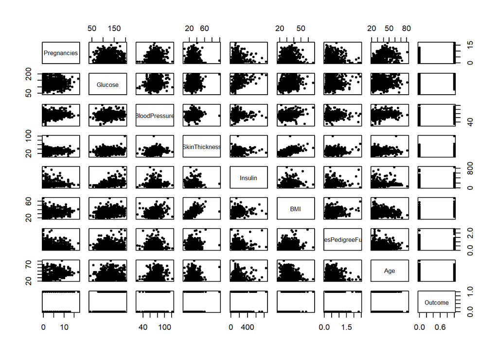

```r
pairs(data,pch=20)
```

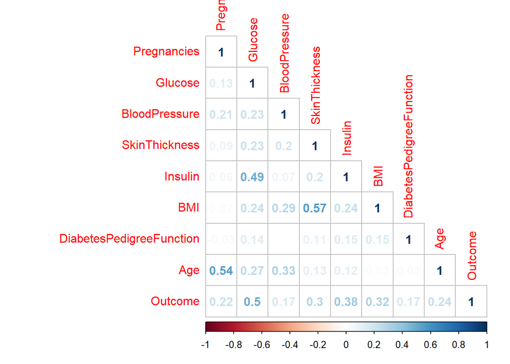

```r
corrplot(cor(data[,-10]),type = "lower", method="number")
```

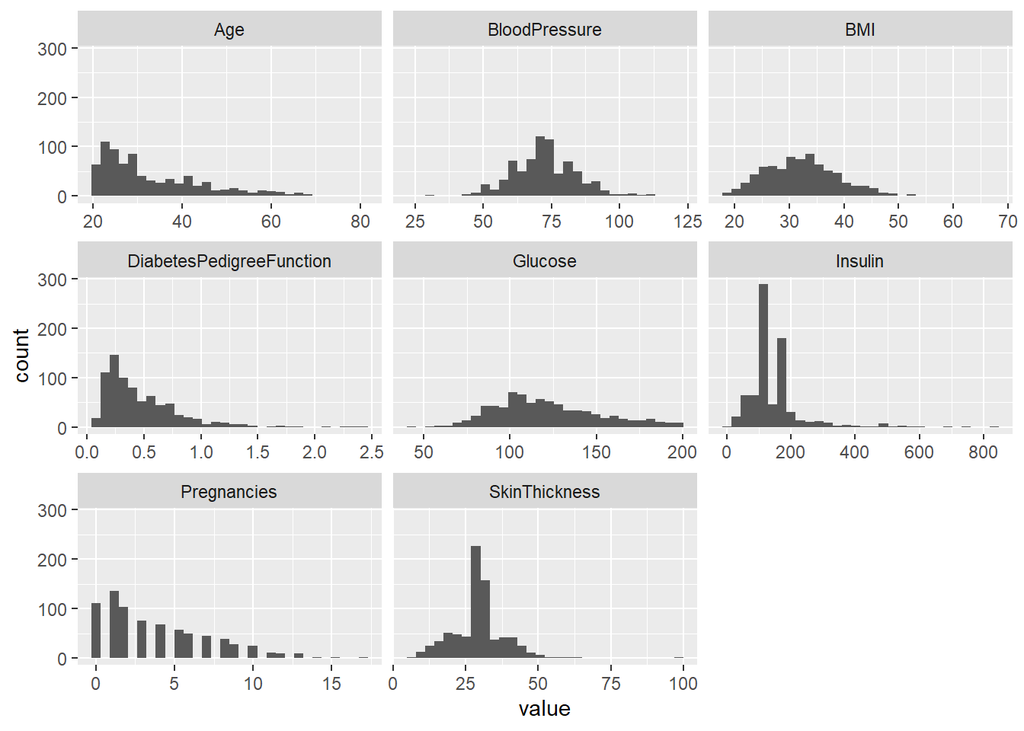

```r
ggplot(gather(data[,-9]),aes(value)) + geom_histogram() + facet_wrap(key~.,scales="free_x")
```

By looking at the scatterplot mattrices, we can make an assumption that the data dots in Skin Thickness might have correlation with BMI. The coefficient in the correlation plot shows 0.57 between BMI and Skin Thickness which means there is a moderate positive relationship. It also shows correlation coefficient of 0.54 between age and pregnancies and 0.49 between Insulin and Glucose. These coefficient measures the strength and direction of a linear relationship between two variables. However, these coefficents we are getting from the scatterplot is not strong enough to assure that their are a significant relationship among the covariates. So we can do further analysis without dropping any columns.

From the ggplot function we can visualize the distribution in each reagressor. BloodPressure and BMI plotS seems to follow a normal distribution. Pregnancies, Age, Insulin and Diebetes Pedigree Function are skewed to the right.

## Model

### Fit logistic regression to the data

```r
model1 = glm(Outcome ~ ., data, family = "binomial")
summary(model1)
```

```
##
## Call:
## glm(formula = Outcome ~ ., family = "binomial", data = data)
##
## Deviance Residuals:
##     Min       1Q   Median       3Q      Max
## -3.6729  -0.6936  -0.3633   0.7078   2.4805
##
## Coefficients:
##                           Estimate Std. Error z value Pr(>|z|)
## (Intercept)              -9.296998   0.832142 -11.172  < 2e-16 ***
## Pregnancies               0.117313   0.032149   3.649 0.000263 ***
## Glucose                   0.030412   0.003888   7.823 5.16e-15 ***
## BloodPressure            -0.004372   0.008801  -0.497 0.619363
## SkinThickness             0.037761   0.013802   2.736 0.006219 **
## Insulin                   0.005394   0.001495   3.608 0.000309 ***
## BMI                       0.058974   0.017992   3.278 0.001047 **
## DiabetesPedigreeFunction  0.787556   0.300863   2.618 0.008854 **
## Age                       0.012985   0.009647   1.346 0.178285
## ---
## Signif. codes:  0 '***' 0.001 '**' 0.01 '*' 0.05 '.' 0.1 ' ' 1
##
## (Dispersion parameter for binomial family taken to be 1)
##
##     Null deviance: 993.48  on 767  degrees of freedom
## Residual deviance: 688.70  on 759  degrees of freedom
## AIC: 706.7
##
## Number of Fisher Scoring iterations: 5
```

```r
set.seed(123)
n <- nrow(data)
train <- sample(n, trunc(0.80*n))
training_data <- data[train, ]
testing_data<- data[-train, ]
```

Total number of Train data rows

```r
nrow(training_data)
```

```
## [1] 614
```

Total number of Test data rows

```r
nrow(testing_data)
```

```
## [1] 154
```

Model Fitting Fitting model using all the independent variables.

```r
estimated_model <- glm(Outcome~.,training_data,family="binomial")
summary(estimated_model)
```

```
##
## Call:
## glm(formula = Outcome ~ ., family = "binomial", data = training_data)
##
## Deviance Residuals:
##     Min       1Q   Median       3Q      Max
## -3.5709  -0.6818  -0.3633   0.6883   2.4604
##
## Coefficients:
##                           Estimate Std. Error z value Pr(>|z|)
## (Intercept)              -9.111210   0.918274  -9.922  < 2e-16 ***
## Pregnancies               0.113641   0.036098   3.148  0.00164 **
## Glucose                   0.032046   0.004447   7.207 5.74e-13 ***
## BloodPressure            -0.006911   0.009902  -0.698  0.48522
## SkinThickness             0.033793   0.015167   2.228  0.02588 *
## Insulin                   0.005109   0.001629   3.135  0.00172 **
## BMI                       0.061468   0.020216   3.041  0.00236 **
## DiabetesPedigreeFunction  0.623525   0.326205   1.911  0.05595 .
## Age                       0.012082   0.010751   1.124  0.26110
## ---
## Signif. codes:  0 '***' 0.001 '**' 0.01 '*' 0.05 '.' 0.1 ' ' 1
##
## (Dispersion parameter for binomial family taken to be 1)
##
##     Null deviance: 796.42  on 613  degrees of freedom
## Residual deviance: 552.36  on 605  degrees of freedom
## AIC: 570.36
##
## Number of Fisher Scoring iterations: 5
```

Predicting Outcome on Training dataset

```r
Predict <- predict (estimated_model,type="response")
summary(Predict)
```

```
##    Min. 1st Qu.  Median    Mean 3rd Qu.    Max.
## 0.01172 0.10282 0.27353 0.35179 0.58994 0.99830
```

The average prediction of each outcome

```r
tapply(Predict,training_data$Outcome,mean)
```

```
##         0         1
## 0.2230124 0.5890791
```

Generating ROC curve on train data

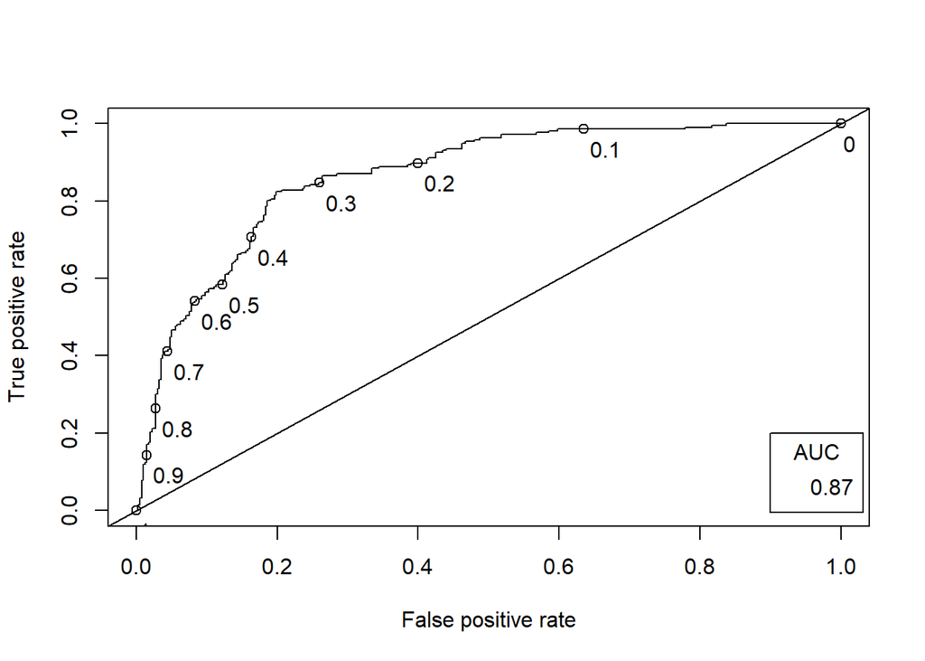

```r
ROC_pre <- prediction(Predict, training_data$Outcome)
ROC_per <- performance(ROC_pre,"tpr","fpr")
plot(ROC_per,print.cutoffs.at= seq(0,1,0.1), text.adj=c(-0.2,1.7))
abline(a=0,b=1)
# Generate AUC curve
AUC <- round(as.numeric(performance(ROC_pre,"auc")@y.values),2)
legend(.9,.2,AUC, title="AUC", cex=1)
```

Making predictions on our Test Data

```r
pred_test <- predict(estimated_model,type = "response",newdata = testing_data)
pred_value <- table(testing_data$Outcome, pred_test>0.5)
pred_value
```

```
##
##     FALSE TRUE
##   0    88   14
##   1    22   30
```

Check the accuracy of the test dataset

```r
Pred_accur <- round(sum(diag(pred_value))/sum(pred_value),2)
Pred_accur
```

```
## [1] 0.77
```

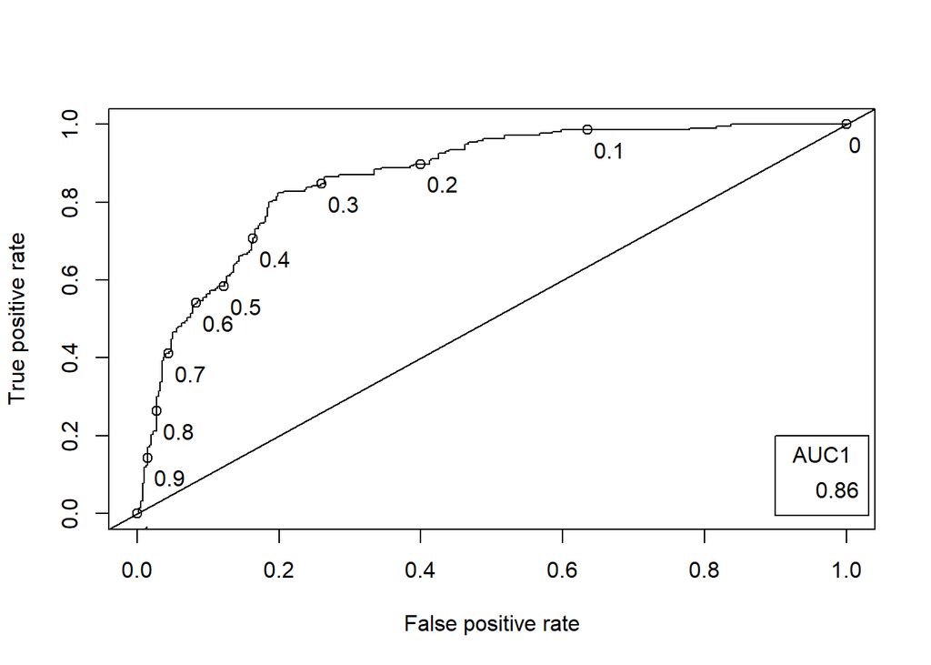

```r
ROC_pretest <- prediction(pred_test, testing_data$Outcome)
ROC_pertest <- performance(ROC_pretest,"tpr","fpr")
plot(ROC_per,print.cutoffs.at= seq(0,1,0.1), text.adj=c(-0.2,1.7))
abline(a=0,b=1)
# Generate AUC curve
AUC1 <- round(as.numeric(performance(ROC_pretest,"auc")@y.values),2)
legend(.9,.2,AUC1, title="AUC1", cex=1)
```

Check the accuracy of the test dataset

```r
AUC1 <- round(as.numeric(performance(ROC_pretest,"auc")@y.values),2)
AUC1
```

```
## [1] 0.86
```

```r
#Not sure about this
estimated_model <- update(estimated_model, ~. - SkinThickness - BloodPressure - Age - DiabetesPedigreeFunction)
summary(estimated_model)
```

```
##
## Call:
## glm(formula = Outcome ~ Pregnancies + Glucose + Insulin + BMI,
##     family = "binomial", data = training_data)
##
## Deviance Residuals:
##     Min       1Q   Median       3Q      Max
## -3.2103  -0.6790  -0.3931   0.6988   2.3830
##
## Coefficients:
##              Estimate Std. Error z value Pr(>|z|)
## (Intercept) -8.689573   0.758380 -11.458  < 2e-16 ***
## Pregnancies  0.129735   0.030605   4.239 2.25e-05 ***
## Glucose      0.032713   0.004283   7.637 2.22e-14 ***
## Insulin      0.005248   0.001610   3.260  0.00112 **
## BMI          0.080899   0.016716   4.840 1.30e-06 ***
## ---
## Signif. codes:  0 '***' 0.001 '**' 0.01 '*' 0.05 '.' 0.1 ' ' 1
##
## (Dispersion parameter for binomial family taken to be 1)
##
##     Null deviance: 796.42  on 613  degrees of freedom
## Residual deviance: 563.45  on 609  degrees of freedom
## AIC: 573.45
##
## Number of Fisher Scoring iterations: 5
```